# A QSP model of covalent KRAS G12C inhibition in NSCLC

Target engagement, adaptive MAPK feedback, resistance, and comparative efficacy

2026-11-05

# 1 Summary

This report documents a quantitative systems pharmacology (QSP) model of covalent KRAS G12C inhibition in previously treated KRAS G12C–mutant non–small-cell lung cancer. The model couples oral pharmacokinetics, covalent engagement of a cycling (GDP/GTP) target, a lumped MAPK pathway with adaptive ERK→upstream negative feedback, and a two-clone tumour (KRAS-dependent sensitive + drug-tolerant resistant). It is calibrated to the published response and progression-free-survival endpoints of sotorasib, adagrasib and docetaxel, then validated out-of-sample and used for in silico trials and dose/schedule/combination exploration.

```
 KRAS G12C QSP <e2><80><94> headline numbers
================================
sotorasib  ORR 41.6% (95% 38.6-44.5), median PFS 6.3 mo, 12-wk occupancy 0.88
adagrasib  ORR 44.4% (95% 41.3-47.5), median PFS 6.9 mo, 12-wk occupancy 0.91
docetaxel  ORR 24.5% (95% 22.1-27.1), median PFS 3.2 mo, 12-wk occupancy 0.00

In silico comparisons (patient CrI):
  sotorasib vs docetaxel: HR 0.69 [0.56, 0.85]
  adagrasib vs docetaxel: HR 0.68 [0.55, 0.83]
  sotorasib vs adagrasib: HR 1.01 [0.83, 1.25]

With parameter (calibration) uncertainty (ensemble 95% CrI):
  HR_soto_doce: HR 0.69 [0.55, 0.91]
  HR_adag_doce: HR 0.66 [0.51, 0.89]
```

# 2 Calibration

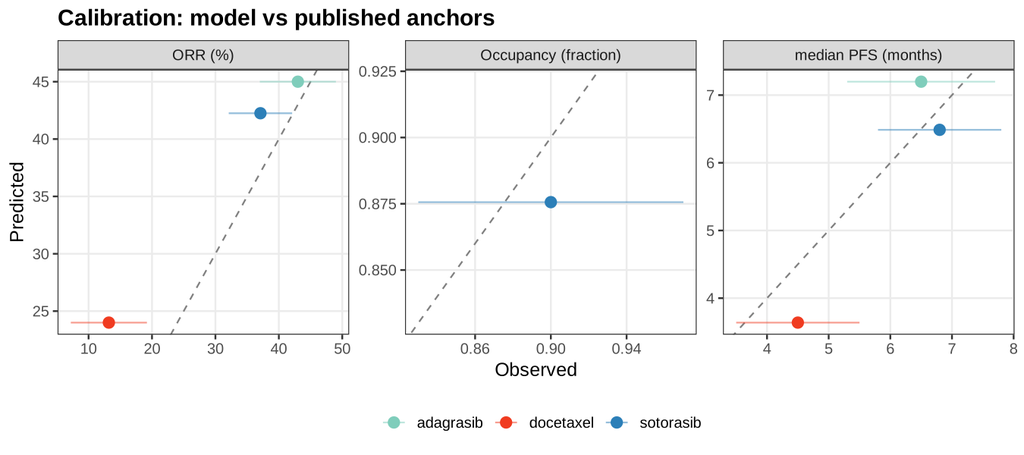

Model vs published anchors.

| tkey | arm | metric | observed | predicted | z | source |
| --- | --- | --- | --- | --- | --- | --- |
| soto_ORR | sotorasib | ORR | 37.1 | 42.25 | 1.03 | CodeBreaK100 |
| soto_PFS | sotorasib | PFS | 6.8 | 6.49 | -0.31 | CodeBreaK100 |
| adag_ORR | adagrasib | ORR | 43.0 | 45.00 | 0.33 | KRYSTAL-1 |
| adag_PFS | adagrasib | PFS | 6.5 | 7.20 | 0.58 | KRYSTAL-1 |
| doce_ORR | docetaxel | ORR | 13.2 | 24.00 | 1.80 | CodeBreaK200 |
| doce_PFS | docetaxel | PFS | 4.5 | 3.64 | -0.86 | CodeBreaK200 |
| soto_occ | sotorasib | occupancy | 0.9 | 0.88 | -0.35 | translational |

Fitted parameters.

| parameter | estimate | lower | upper |
| --- | --- | --- | --- |
| fb | 2.600 | 0.200 | 4.00 |
| kprog | 0.007 | 0.002 | 0.08 |
| kcov_soto | 14.825 | 2.000 | 40.00 |
| kcov_adag | 22.000 | 2.000 | 60.00 |
| kkill | 0.032 | 0.015 | 0.12 |
| dep | 0.330 | 0.150 | 0.95 |
| bypass | 0.850 | 0.500 | 0.99 |
| fr0 | 0.300 | 0.020 | 0.30 |
| kres | 0.004 | 0.002 | 0.02 |
| kkill_doce | 0.009 | 0.002 | 0.06 |
| kprog_doce | 0.016 | 0.004 | 0.05 |

# 3 Target engagement, signalling and tumour dynamics

The irreversible inhibitor captures GDP-bound KRAS G12C; ERK suppression releases the upstream brake, raising the activation input (adaptive reactivation). A typical sotorasib patient:

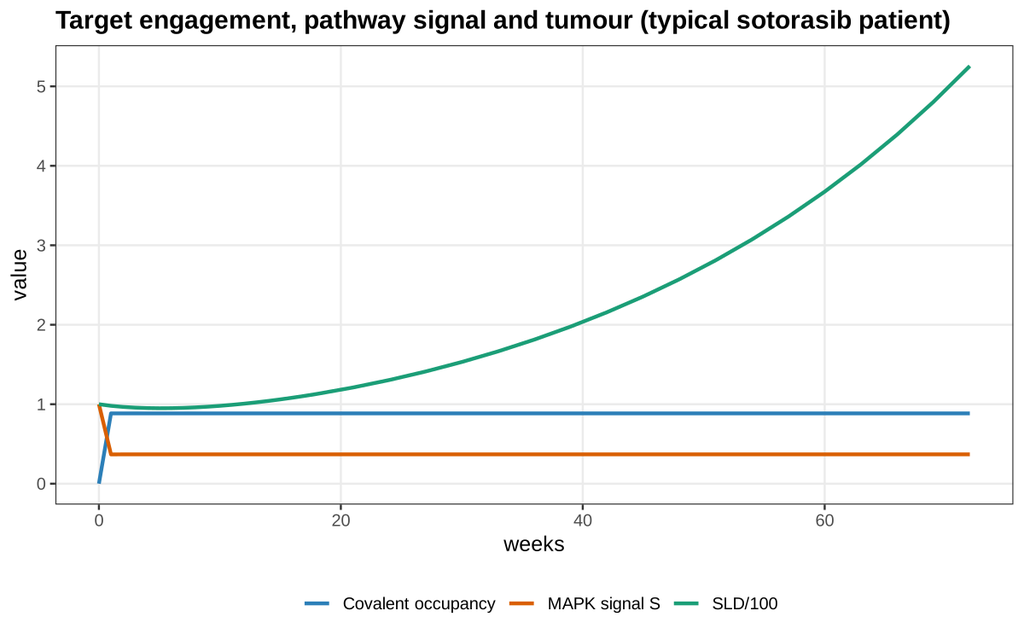

# 4 Response and progression-free survival (virtual population)

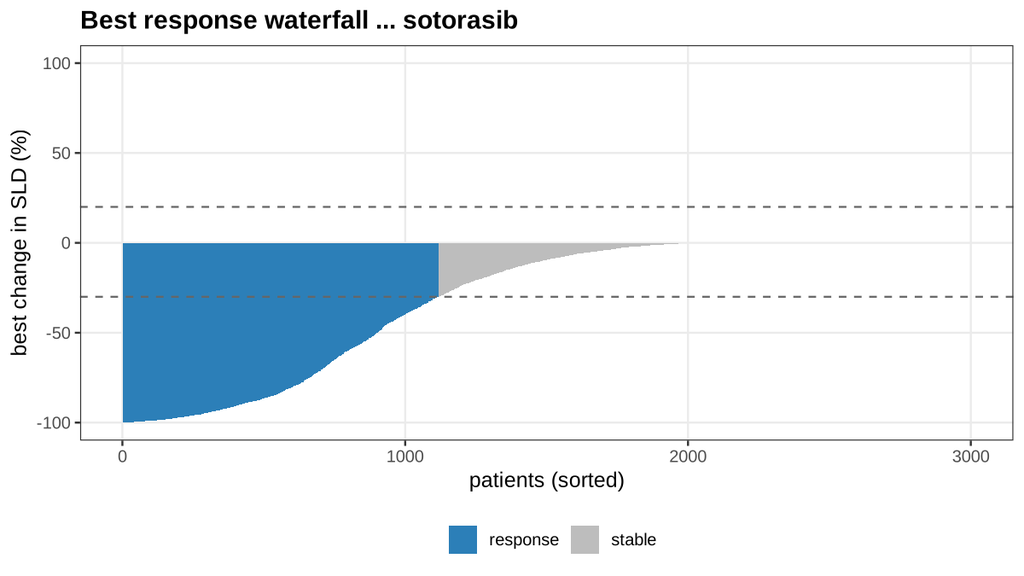

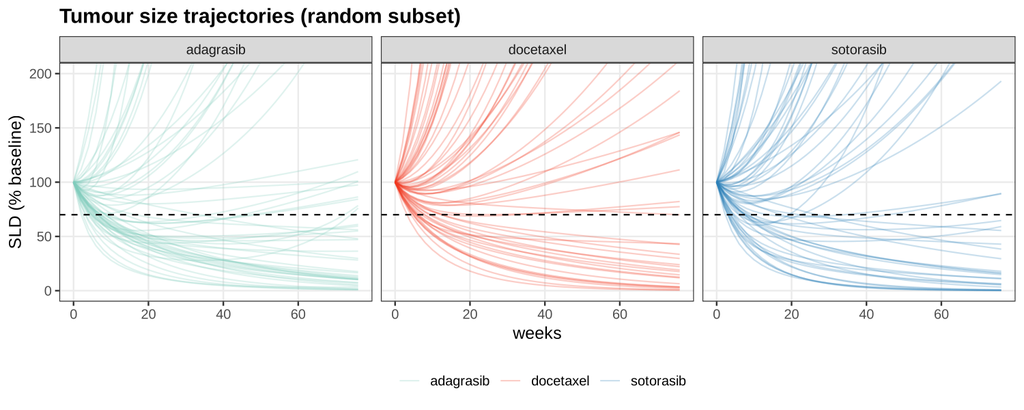

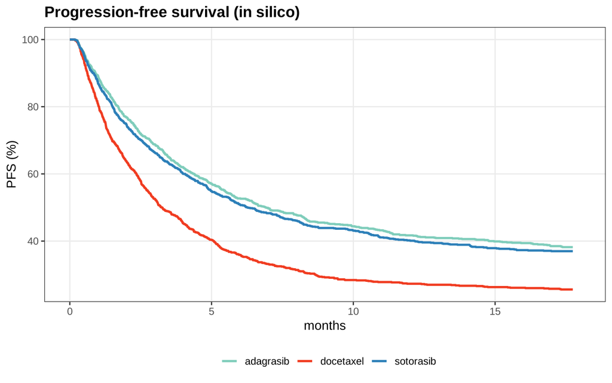

Virtual-population outcomes.

| arm | n | ORR | ORR_lo | ORR_hi | medPFS | mean_occ84 |
| --- | --- | --- | --- | --- | --- | --- |
| sotorasib | 1000 | 41.6 | 38.5975 | 44.5 | 6.268879 | 0.8757380 |
| adagrasib | 1000 | 44.4 | 41.2975 | 47.5 | 6.915415 | 0.9085326 |
| docetaxel | 1000 | 24.5 | 22.1000 | 27.1 | 3.248179 | 0.0000000 |

# 5 In silico head-to-head trial

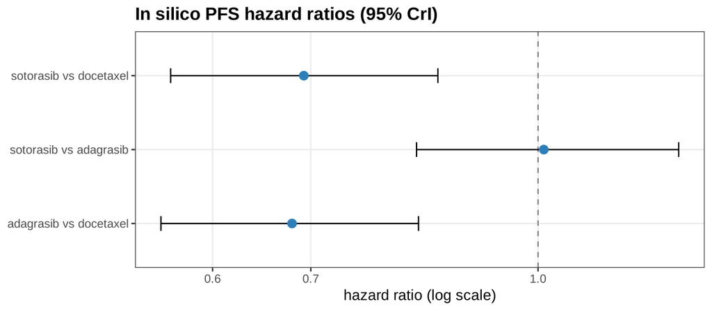

Randomised in silico comparisons (median [95% CrI]).

| comparison | HR | HR_lo | HR_hi | ORRdiff | ORRdiff_lo | ORRdiff_hi | medPFS_A | medPFS_B |
| --- | --- | --- | --- | --- | --- | --- | --- | --- |
| sotorasib vs docetaxel | 0.6923683 | 0.5617440 | 0.8544985 | 16.16667 | 8.666667 | 23.84167 | 6.080361 | 3.242775 |
| adagrasib vs docetaxel | 0.6796860 | 0.5532904 | 0.8289209 | 18.33333 | 11.666667 | 26.17500 | 6.104940 | 3.243180 |
| sotorasib vs adagrasib | 1.0090786 | 0.8263734 | 1.2470410 | -2.00000 | -10.175000 | 6.00000 | 5.987724 | 6.021207 |

# 6 Parameter (calibration) uncertainty

The virtual-population and in-silico intervals above propagate **patient (trial-to-trial)** variability at the point-estimate parameters. Here we also propagate **calibration uncertainty**: an approximate 95% joint-confidence-region ensemble of parameter sets (Latin-hypercube over the prior box, accepted by the likelihood-ratio threshold `obj_min + qchisq(0.95, n_params)`). The per-parameter 95% ensemble range doubles as a marginal profile-likelihood-style interval.

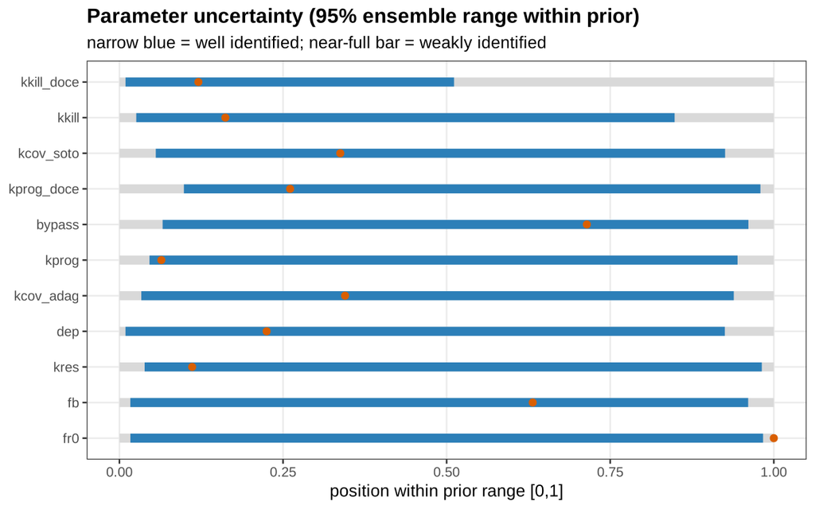

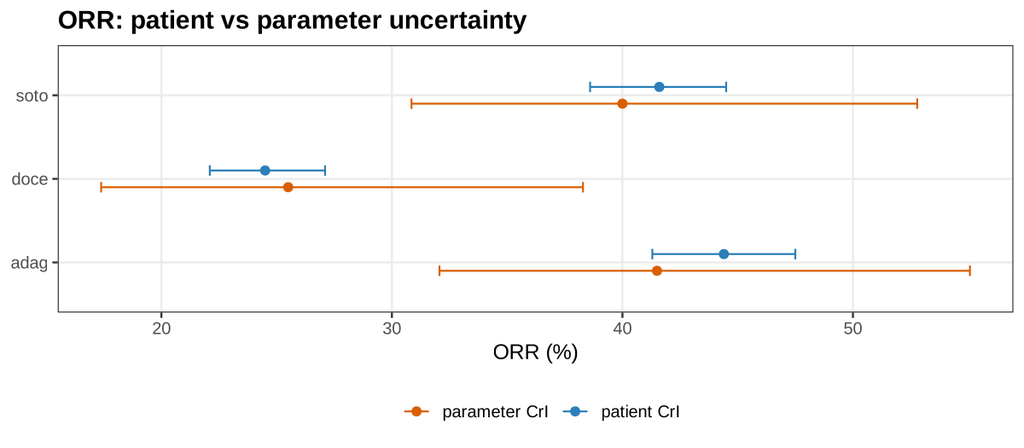

Predictions with parameter uncertainty (ensemble 95% CrI). The hazard ratios are robust; absolute ORR/PFS widen, driven by the weakly-identified resistance parameters.

| quantity | median | lo95 | hi95 |
| --- | --- | --- | --- |
| soto_ORR | 40.00 | 30.85 | 52.79 |
| soto_PFS | 4.31 | 2.63 | 10.45 |
| adag_ORR | 41.50 | 32.06 | 55.08 |
| adag_PFS | 4.63 | 3.05 | 11.89 |
| doce_ORR | 25.50 | 17.39 | 38.29 |
| doce_PFS | 2.82 | 1.72 | 3.85 |
| HR_soto_doce | 0.69 | 0.55 | 0.91 |
| HR_adag_doce | 0.66 | 0.51 | 0.89 |

# 7 Out-of-sample validation

Leave-one-drug-out and temporal validation; pass = within pre-specified tolerance.

| scheme | held_out | target | metric | observed | predicted | abs_err | pass |
| --- | --- | --- | --- | --- | --- | --- | --- |
| LODO | sotorasib | soto_ORR | ORR | 37.1 | 34.57 | 2.53 | TRUE |
| LODO | sotorasib | soto_PFS | PFS | 6.8 | 4.31 | 2.49 | FALSE |
| LODO | sotorasib | soto_occ | occupancy | 0.9 | 0.87 | 0.03 | TRUE |
| LODO | adagrasib | adag_ORR | ORR | 43.0 | 38.86 | 4.14 | TRUE |
| LODO | adagrasib | adag_PFS | PFS | 6.5 | 4.73 | 1.77 | FALSE |
| LODO | docetaxel | doce_ORR | ORR | 13.2 | 22.57 | 9.37 | TRUE |
| LODO | docetaxel | doce_PFS | PFS | 4.5 | 3.04 | 1.46 | TRUE |
| TEMPORAL(fit ORR->predict PFS) | all PFS | soto_PFS | PFS | 6.8 | 4.18 | 2.62 | FALSE |
| TEMPORAL(fit ORR->predict PFS) | all PFS | adag_PFS | PFS | 6.5 | 4.48 | 2.02 | FALSE |
| TEMPORAL(fit ORR->predict PFS) | all PFS | doce_PFS | PFS | 4.5 | 1.28 | 3.22 | FALSE |

# 8 Identifiability

Prior->posterior shrinkage and practical identifiability.

| parameter | estimate | se | post95_width | prior_width | shrinkage | identified |
| --- | --- | --- | --- | --- | --- | --- |
| kcov_adag | 22.000 | 0.1817442 | 0.7124374 | 58.000 | 0.9877166 | yes |
| kcov_soto | 14.825 | 0.1814849 | 0.7114207 | 38.000 | 0.9812784 | yes |
| fb | 2.600 | 0.1815789 | 0.7117893 | 3.800 | 0.8126870 | yes |
| fr0 | 0.300 | 0.0176262 | 0.0690948 | 0.280 | 0.7532327 | yes |
| dep | 0.330 | 0.1529475 | 0.5995542 | 0.800 | 0.2505573 | partial |
| bypass | 0.850 | 0.1008608 | 0.3953742 | 0.490 | 0.1931139 | weak |
| kprog | 0.007 | 0.1555950 | 0.6099323 | 0.078 | 0.0000000 | no |
| kkill | 0.032 | 0.1807872 | 0.7086858 | 0.105 | 0.0000000 | no |
| kres | 0.004 | 0.0947328 | 0.3713525 | 0.018 | 0.0000000 | no |
| kkill_doce | 0.009 | 0.0987218 | 0.3869894 | 0.058 | 0.0000000 | no |
| kprog_doce | 0.016 | 0.1526986 | 0.5985787 | 0.046 | 0.0000000 | no |

````
##
## ```
##  Structural / a-priori identifiability notes:
## - Covalent potency (kcov_*) and free-exposure scale are only jointly identified; the exposure
##   scale (Cref) is fixed from PK so kcov_* carries the engagement efficiency.
## - Effect-site partition is not identifiable from these endpoints; effect-site = free plasma (fixed).
## - kprol and kdeath0 trade off in the net growth rate; only the net rate is informed, so both are
##   fixed from natural-history doubling time and only drug/resistance parameters are estimated.
## - A full differential-algebra structural analysis is out of scope; practical identifiability is
##   assessed here by the Hessian covariance, prior->posterior shrinkage and the objective profiles.
## ```
````

# 9 Global sensitivity

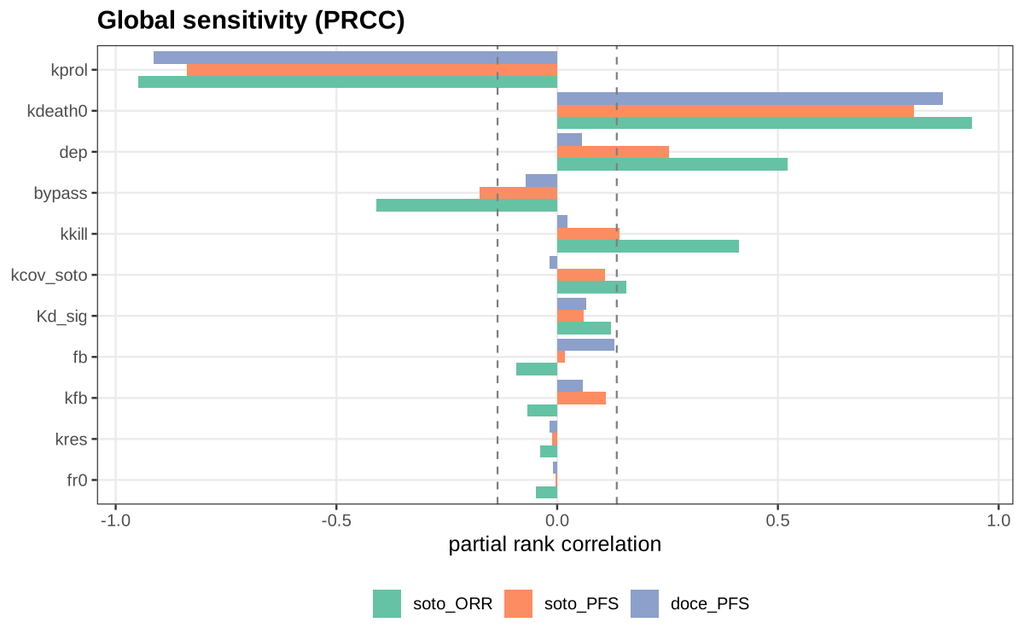

Partial rank correlation of outputs on parameters.

| parameter | soto_ORR | soto_PFS | doce_PFS | signif_band |
| --- | --- | --- | --- | --- |
| kprol | -0.948 | -0.838 | -0.915 | 0.135 |
| kdeath0 | 0.939 | 0.809 | 0.874 | 0.135 |
| dep | 0.522 | 0.253 | 0.056 | 0.135 |
| bypass | -0.410 | -0.175 | -0.071 | 0.135 |
| kkill | 0.411 | 0.141 | 0.024 | 0.135 |
| kfb | -0.067 | 0.110 | 0.059 | 0.135 |
| kcov_soto | 0.156 | 0.108 | -0.018 | 0.135 |
| Kd_sig | 0.122 | 0.061 | 0.066 | 0.135 |
| fb | -0.092 | 0.017 | 0.129 | 0.135 |
| kres | -0.038 | -0.011 | -0.017 | 0.135 |
| fr0 | -0.049 | -0.004 | -0.010 | 0.135 |

# 10 Structural model qualification

Each mechanism is tested by refitting a reduced variant that disables it and comparing fit by an AIC-like score (objective + 2·n_free). A large dAIC when a mechanism is removed means the data warrant it.

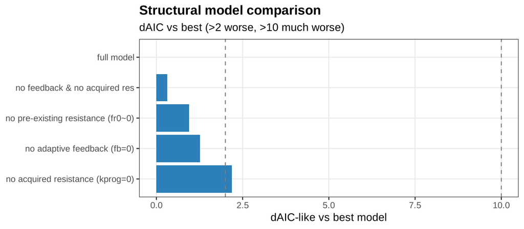

Reduced structures refit and compared; dAIC vs the best model.

| model | n_free | objective | AIC_like | soto_ORR | soto_PFS | adag_ORR | adag_PFS | doce_ORR | doce_PFS | dAIC |
| --- | --- | --- | --- | --- | --- | --- | --- | --- | --- | --- |
| full model | 11 | 3.66 | 25.66 | 39.8 | 6.2 | 43.0 | 6.8 | 22.8 | 3.2 | 0.00 |
| no feedback & no acquired res | 9 | 7.97 | 25.97 | 43.8 | 5.7 | 44.2 | 6.1 | 30.0 | 4.3 | 0.31 |
| no pre-existing resistance (fr0~0) | 10 | 6.61 | 26.61 | 39.2 | 5.1 | 43.0 | 5.9 | 26.5 | 3.9 | 0.95 |
| no adaptive feedback (fb=0) | 10 | 6.93 | 26.93 | 42.8 | 5.7 | 43.5 | 5.9 | 28.5 | 3.9 | 1.27 |
| no acquired resistance (kprog=0) | 10 | 7.85 | 27.85 | 44.0 | 7.7 | 46.5 | 8.1 | 23.2 | 3.1 | 2.19 |

# 11 External benchmark (MBMA)

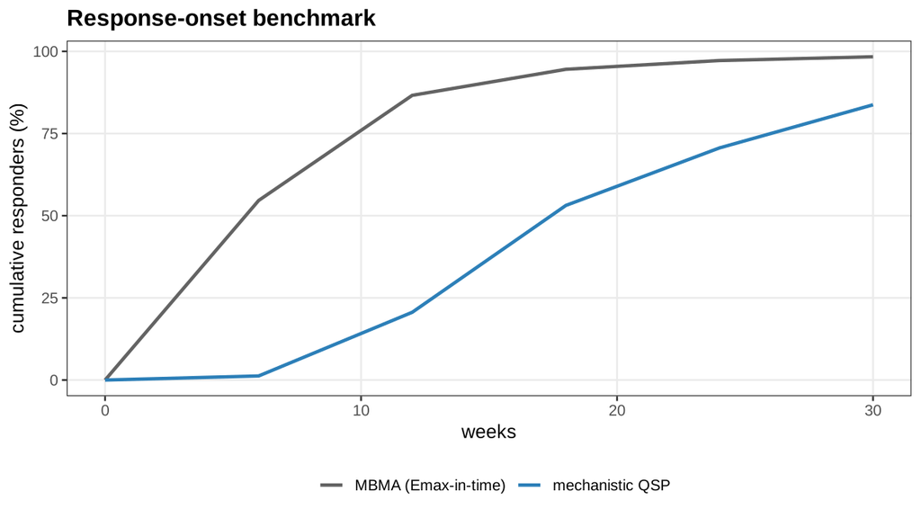

Mechanistic ORR vs cross-programme MBMA pool.

| drug | arm | obs_ORR | mech_ORR | mbma_pooled |
| --- | --- | --- | --- | --- |
| adagrasib | KRYSTAL-1 | 42.9 | 42.6 | 35.71412 |
| sotorasib | CodeBreaK100 | 37.1 | 39.6 | 35.71412 |
| sotorasib | CodeBreaK200 | 28.1 | 39.6 | 35.71412 |

# 12 Scenario exploration

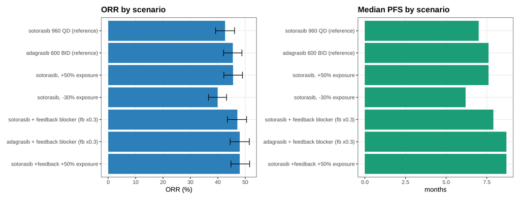

Dose/schedule and feedback-blocking scenarios (in silico hypotheses).

| scenario | arm | dose_factor | fb_scale | ORR | ORR_lo | ORR_hi | medPFS | nadir_med |
| --- | --- | --- | --- | --- | --- | --- | --- | --- |
| sotorasib 960 QD (reference) | sotorasib | 1.0 | 1.0 | 42.6 | 39.2 | 46.1 | 7.0 | 85.5 |
| adagrasib 600 BID (reference) | adagrasib | 1.0 | 1.0 | 45.5 | 42.1 | 48.8 | 7.6 | 81.0 |
| sotorasib, +50% exposure | sotorasib | 1.5 | 1.0 | 45.6 | 42.2 | 49.0 | 7.6 | 80.9 |
| sotorasib, -30% exposure | sotorasib | 0.7 | 1.0 | 39.9 | 36.6 | 43.2 | 6.2 | 89.6 |
| sotorasib + feedback blocker (fb x0.3) | sotorasib | 1.0 | 0.3 | 47.1 | 43.5 | 50.5 | 7.9 | 78.1 |
| adagrasib + feedback blocker (fb x0.3) | adagrasib | 1.0 | 0.3 | 48.0 | 44.5 | 51.5 | 8.7 | 73.8 |
| sotorasib +feedback +50% exposure | sotorasib | 1.5 | 0.3 | 48.0 | 44.8 | 51.6 | 8.7 | 73.6 |

# 13 Limitations

Effect-site is free plasma; the MAPK cascade is lumped to one ppERK output; resistance is two compartments plus a pre-existing fraction, not an explicit mutational spectrum; calibration uses summary-level published endpoints, not individual patient data. This is a research / educational in silico model and is **not** a clinical decision tool.